# Lesson 2 - Frequency and Response Latencies

01/16/2019

## Language Topics Discussed

- English Lexicon Project
- The Subtitle Projects
- Extension to Priming Projects

## English Lexicon Project

- http://elexicon.wustl.edu/
- ELP was a large undertaking that helped kick start the recent uptick in standardized behavioral data for language researchers
  - Corpora have been around, so have databases, but in the last 10 years, this field has grown exponentially
- The data contains 40K + words and 40K + nonwords with many characteristics
- Lexical Decision and Naming Tasks included

## English Lexicon Project

- https://www.psytoolkit.org/experiment-library/ldt.html
  - However, you would only see one word at a time (in this example you see two)
- In the naming task, you would be asked to read those words aloud, one at a time
- Output we are interested in is how the lexical variables might predict the response latencies

## Subtitle Projects

- Starting with Brysbaert and New (several papers), there was a movement to rethink frequency and its relation to predicting language results
- Traditionally, two sources of frequency were used:
  - The Brown Corpus: Kucera and Francis (1967)
  - HAL Corpus: Burgess and Livesay (1998)
- However, we weren’t sure these were the best estimators of frequency

## Subtitle Projects

- http://subtlexus.lexique.org/
- Downloaded subtitles from www.opensubtitles.org with 50 million words+
- Provided both estimates for subtitles and music lyrics
- Models estimating lexical decision and naming times indicate these estimations of frequency are better predictors
- Expanded to 15-20 different languages

## The Semantic Priming Project

- Priming occurs when cognitive processing is speeded because of a previous event
- Generally, we measure priming using lexical decision and naming tasks
- Let’s say you have two trials:
  - DOCTOR –> TREE (unrelated)
  - DOCTOR –> NURSE (related)

## The Semantic Priming Project

- Priming is thought to occur by several different mechanisms: spreading activation, deliberate cognitive processes such as expectancy generation, etc.

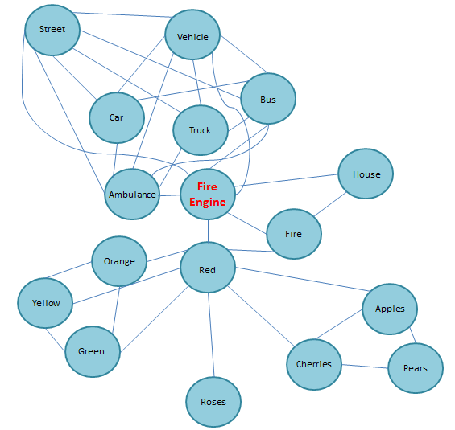

## The Semantic Priming Project

- Contains lexical decision and naming response latencies for related, unrelated, and nonword trials
- Is paired with the ELP and SUBTLEX projects
- Gives us more data to predict either response latencies or priming latencies

## Regression

- Simple regression is the relationship between one independent and one dependent variable (also correlation)
- Multiple regression is the relationship between two or more independent variables and one dependent variable
  - Useful because it allows you to examine the predictive ability of each variable adjusting for the other variables
- We can fit parametric (linear) models or nonparametric models, depending on the expectation of linearity, as well as the type of dependent variable

## Understand Regression Models

\[{\hat{y_i}} = b_0 + b_1x_{1i} + b_2x_{2i} ... + \epsilon_i\]

- Y-hat is the predicted score for each person (i) on the dependent variable
- B-zero is the y-intercept
- B-1+ are the slope values for each predictor
  - Slopes are interpreted as *for every one unit increase in X, we see B unit increases in Y*
- X is each individual predictor
- Error for each individual person, as we never get their predicted score exactly right

## Understand Regression Models

- Least Squares estimation
  - Creates the line of best fit by minimizing the residual error \(\epsilon\)

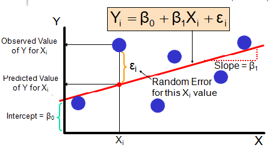

## Understand Regression Models

- For the overall model including all variables:
  - Determine statistical significance by using *p* values from an *F*-test for linear models
  - Determine practical significance by using \(R^2\)
- For the individual predictors:
  - Determine statistical significance by using *p* values from a *t*-test
  - Determine practical significance by using partial correlation \(pr^2\)

## Examples Using ELP

- Word is the word presented to the participant
- Length is the number of characters in each word
- SUBTLWF is the subtitle word frequency estimate
- POS is part of speech
- Mean_RT is the mean response latency in milliseconds

```r
library(Rling)
data(ELP)
head(ELP)
```

```
##         Word Length SUBTLWF POS Mean_RT
## 1    rackets      7    0.96  NN  790.87
## 2 stepmother     10    4.24  NN  692.55
## 3 delineated     10    0.04  VB  960.45
## 4   swimmers      8    1.49  NN  771.13
## 5     umpire      6    1.06  NN  882.50
## 6      cobra      5    3.33  NN  645.85
```

## Dealing with Categorical Predictors

- How can we interpret and use categorical predictors?
- When X is continuous, the interpretation is that *for every one unit increase in X, we see B unit increases in Y*
- That doesn’t work as well for categorical predictors…
- Instead, we have to use Dummy Coding (well, *R* does it for us)

## Dummy Coding

- A way to represent categorical data for regression/least squares analyses
- You will get (categories - 1) predictors
- How to interpret these predictors?
  - Each predictor represents the difference in means between the coded group (the one with the 1) and the group coded as all zeroes (the “control” group)

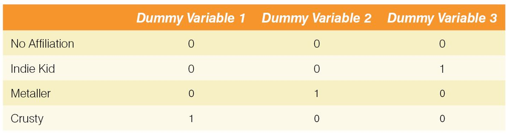

## Dummy Coding

- POS is a categorical predictor we want to use
- Three categories:
  - JJ: Adjective
  - NN: Noun
  - VB: Verb
- Default is to make the first category the comparison category

```r
table(ELP$POS)
```

```
##
##  JJ  NN  VB
## 159 532 189
```

## Dummy Coding

- Generally, nouns would be considered the comparison group, so let’s rearrange them so they are “first”.

```r
ELP$POS = factor(ELP$POS, #the column you want to update
                 #the values in the data in the order you want
                 levels = c("NN", "JJ", "VB"),
                 #give them better labels if you want
                 labels = c("Noun", "Adjective", "Verb"))
table(ELP$POS)
```

```
##
##      Noun Adjective      Verb
##       532       159       189
```

## Dealing with Non-Normal Data

- One issue in language research is that often we have non-normal data
- Especially when working with frequency (as it is distributed by Zipf’s law)

## Dealing with Non-Normal Data

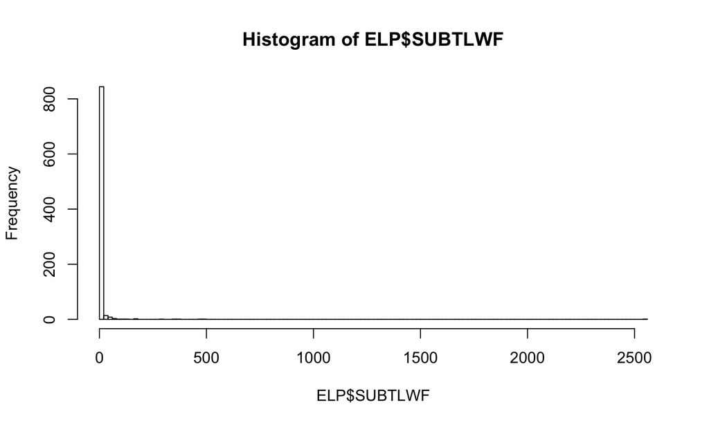

```r
hist(ELP$SUBTLWF, breaks = 100)
```

## Dealing with Non-Normal Data

- The simplest solution is to take the `log` of the variable.
- Does make interpretation a bit more difficult, but helps with the distribution of the data.

## Dealing with Non-Normal Data

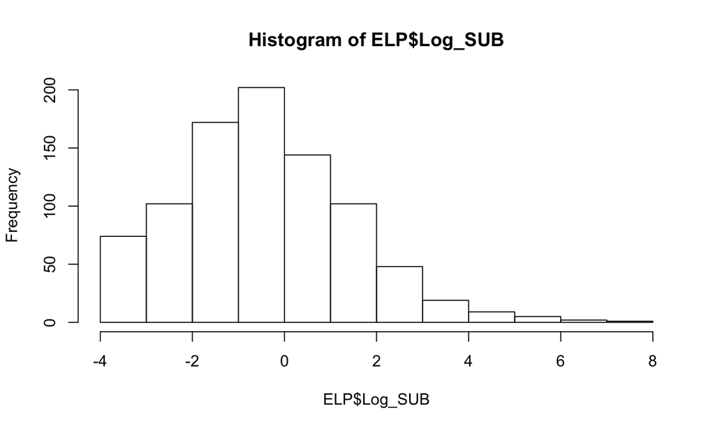

```r
ELP$Log_SUB = log(ELP$SUBTLWF)
hist(ELP$Log_SUB)
```

## Build the Linear Model

- To be able to use our output for several purposes, we want to save it
  - You can call it whatever you want, I like `model`.
- Format for `lm` function is:
  - Y ~ X + X + …
  - data = name of data frame

```r
model = lm(Mean_RT ~ Length + Log_SUB + POS,
           data = ELP)
```

## Summarize the Linear Model

```r
summary(model)
```

```
##
## Call:
## lm(formula = Mean_RT ~ Length + Log_SUB + POS, data = ELP)
##
## Residuals:
##     Min      1Q  Median      3Q     Max
## -213.70  -62.55   -9.71   53.87  389.00
##
## Coefficients:
##              Estimate Std. Error t value Pr(>|t|)
## (Intercept)   616.351     12.233  50.385  < 2e-16 ***
## Length         19.555      1.433  13.645  < 2e-16 ***
## Log_SUB       -29.288      1.784 -16.420  < 2e-16 ***
## POSAdjective    6.115      8.506   0.719  0.47238
## POSVerb       -23.069      7.918  -2.913  0.00367 **
## ---
## Signif. codes:  0 '***' 0.001 '**' 0.01 '*' 0.05 '.' 0.1 ' ' 1
##
## Residual standard error: 93.29 on 875 degrees of freedom
## Multiple R-squared:  0.4565, Adjusted R-squared:  0.454
## F-statistic: 183.7 on 4 and 875 DF,  p-value: < 2.2e-16
```

## Residuals

- A summary of the residuals - remember that residuals are the error terms or how far off we were at predicting the Mean_RT
- We will use this information as part of our assumptions diagnostics for data screening

```r
summary(model$residuals)
```

```
##     Min.  1st Qu.   Median     Mean  3rd Qu.     Max.
## -213.699  -62.551   -9.714    0.000   53.874  388.998
```

## Coefficients

```r
options(scipen = 999)
round(summary(model)$coefficients, 3)
```

```
##              Estimate Std. Error t value Pr(>|t|)
## (Intercept)   616.351     12.233  50.385    0.000
## Length         19.555      1.433  13.645    0.000
## Log_SUB       -29.288      1.784 -16.420    0.000
## POSAdjective    6.115      8.506   0.719    0.472
## POSVerb       -23.069      7.918  -2.913    0.004
```

## Coefficients

- To interpret categorical predictors, it can help to make a means table
- Now I can see that verbs are responded to faster than nouns, interpreting the categorical predictor

```r
tapply(ELP$Mean_RT, #dv
       ELP$POS, #iv group variable
       mean) #function
```

```
##      Noun Adjective      Verb
##  787.5959  822.9145  754.3316
```

## Coefficient Confidence Intervals

- We can calculate the confidence intervals for the coefficients, to help understand their precision

```r
confint(model)
```

```
##                  2.5 %    97.5 %
## (Intercept)  592.34193 640.36007
## Length        16.74194  22.36757
## Log_SUB      -32.78872 -25.78704
## POSAdjective -10.57915  22.80935
## POSVerb      -38.61021  -7.52737
```

## Coefficient Practical Importance

- Calculate \(pr^2\): variance accounted for in the DV by that IV after removing all variance due to other IVs

\[ \frac{t_{x_i}}{\sqrt{t_{x_i}^2 + df_{res}}} \]

```r
t = summary(model)$coefficients[-1 , 3]
pr = t / sqrt(t^2 + model$df.residual)
pr^2
```

```
##       Length      Log_SUB POSAdjective      POSVerb
## 0.1754422571 0.2355448602 0.0005903474 0.0096065265
```

## Overall Model

- So how much better than a random guess are we at predicting?
  - A good random guess is always the y-intercept or the mean of y.
- The *F*-statistic represents the difference of the model from zero

```r
summary(model)$fstatistic
```

```
##    value    numdf    dendf
## 183.7024   4.0000 875.0000
```

## Overall Model

- \(R^2\) represents the overlap in all IV variance with the DV variance

```r
summary(model)$r.squared
```

```
## [1] 0.4564574
```

## Diagnostic Tests

- Outliers and influential observations: data points that have large residuals or are otherwise odd in relation to the rest of the data
- Assumptions of parametric regression:
  - Independence
  - DV is response scale
  - Additivity (no multicollinearity)
  - Linearity
  - Normality
  - Homoscedasticity/Homogeneity

## Outliers

- Hat values (or leverage): indicates how much influence on the slope a data point has
- Studentized residuals: the normalized (z-scored) difference between a participant’s predicted and actual score
- Cook’s values: a measure of influence (both leverage and discrepancy)

## Outliers

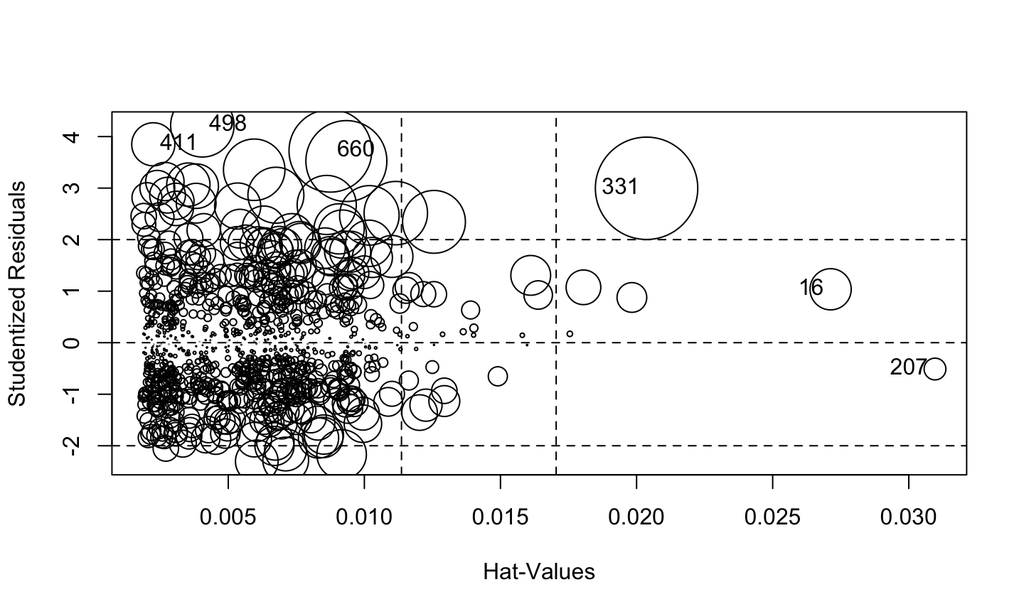

```
##        StudRes         Hat       CookD
## 16   1.0366190 0.027128347 0.005992376
## 207 -0.5110465 0.030963411 0.001670423
## 331  2.9961984 0.020366762 0.036990327
## 411  3.8500613 0.002244803 0.006566174
## 498  4.2181812 0.004047706 0.014190408
## 660  3.7238861 0.008750676 0.024129118
```

```r
library(car)
influencePlot(model)
```

## Outliers

- What do we do with them?

```r
ELP[c(331,660,498,411), ]
```

```
##                  Word Length SUBTLWF       POS Mean_RT    Log_SUB
## 331 interdepartmental     17    0.04 Adjective 1324.57 -3.2188758
## 660      sacrilegious     12    0.39 Adjective 1228.06 -0.9416085
## 498           whippet      7    0.10      Noun 1209.67 -2.3025851
## 411         archenemy      9    0.25      Noun 1188.91 -1.3862944
```

## Assumptions

- Independence - the data is independent from each other (i.e. each data point is from a different “person”)
- Interval scale dependent variable: check!

## Additivity

- No correlation between predictors above .9 (but .7 is actually not good either)

```r
summary(model, correlation = T)$correlation[ , -1]
```

```
##                   Length      Log_SUB POSAdjective      POSVerb
## (Intercept)  -0.94238493 -0.272940500  -0.09904041 -0.232585764
## Length        1.00000000  0.340416664  -0.05527619  0.066688453
## Log_SUB       0.34041666  1.000000000   0.09363100  0.006852748
## POSAdjective -0.05527619  0.093631001   1.00000000  0.237177357
## POSVerb       0.06668845  0.006852748   0.23717736  1.000000000
```

## Additivity

- Small Variance Inflation Scores (VIF) values (less than 5 to 10)

```r
vif(model)
```

```
##             GVIF Df GVIF^(1/(2*Df))
## Length  1.151054  1        1.072872
## Log_SUB 1.150140  1        1.072446
## POS     1.026925  2        1.006664
```

## Linearity

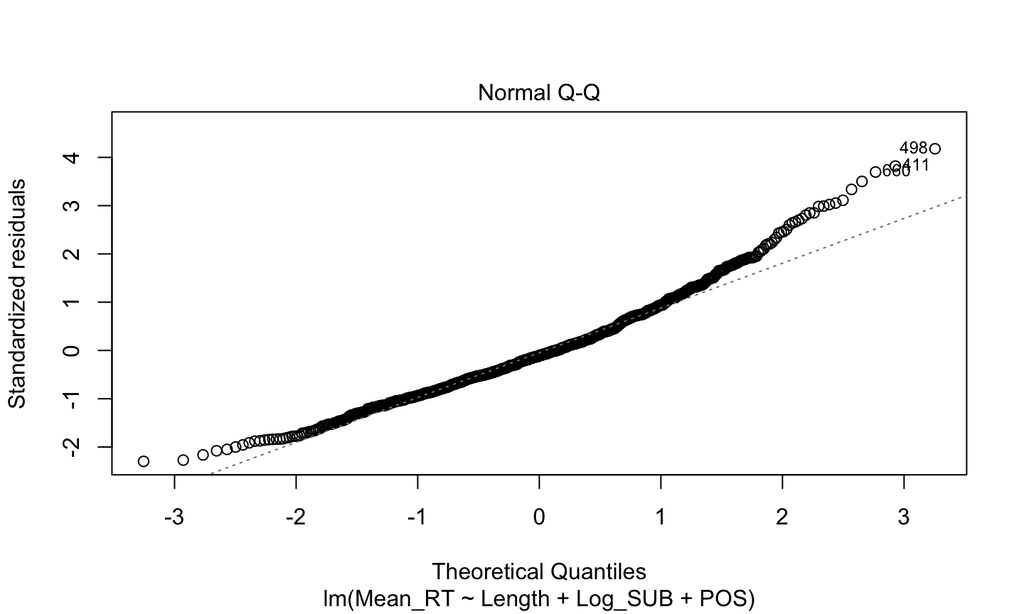

```r
plot(model, which = 2)
```

## Normality

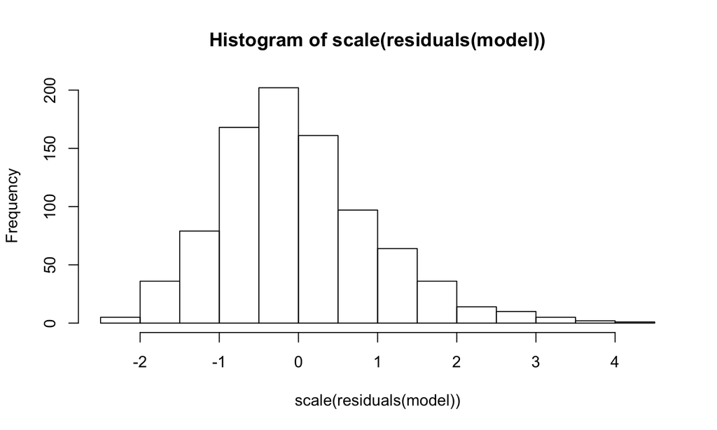

```r
hist(scale(residuals(model)))
```

## Homoscedasticity/Homogeneity

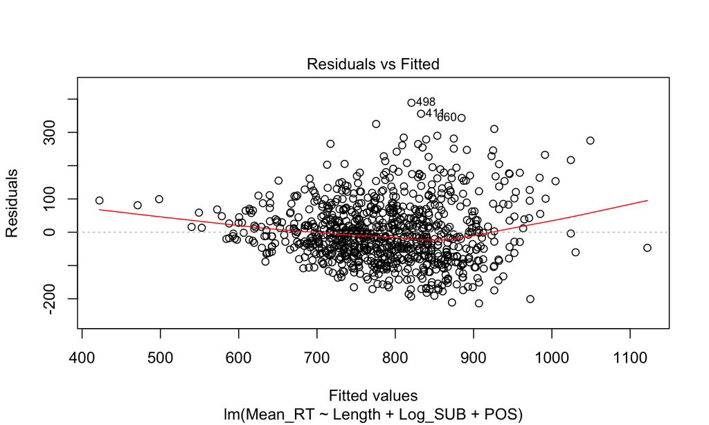

```r
plot(model, which = 1)
```

## Homoscedasticity/Homogeneity

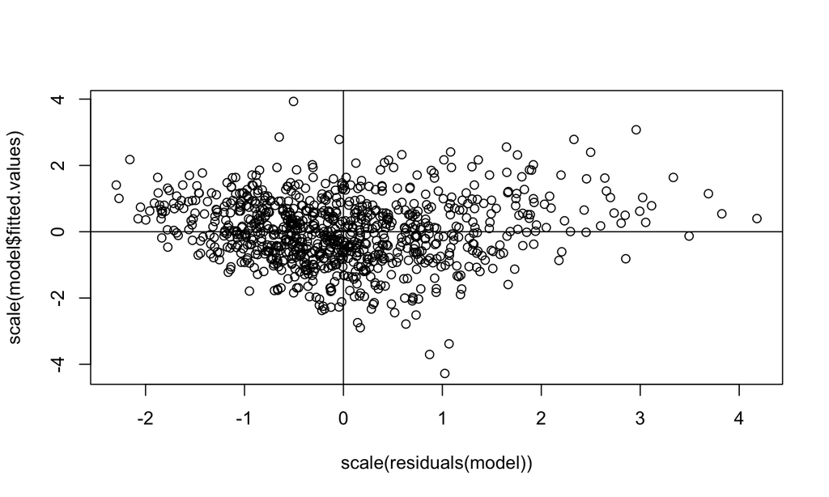

```r
{plot(scale(residuals(model)), scale(model$fitted.values))
  abline(v = 0, h = 0)}
```

## One Solution to Bad Assumptions

- First, build a function that saves the numbers you want:

```r
bootcoef = function(formula, data, indices){
  d = data[indices, ] #randomize the data by row
  model = lm(formula, data = d) #run our model
  return(coef(model)) #give back coefficients
}
```

## Bootstrapping

- Next, use the `boot` library to run the bootstraps (lots of runs on randomly sampled data)

```r
library(boot)
model.boot = boot(formula = Mean_RT ~ Length + Log_SUB + POS,
                  data = ELP,
                  statistic = bootcoef,
                  R = 1000)
```

## Bootstrapping

```r
model.boot
```

```
##
## ORDINARY NONPARAMETRIC BOOTSTRAP
##
##
## Call:
## boot(data = ELP, statistic = bootcoef, R = 1000, formula = Mean_RT ~
##     Length + Log_SUB + POS)
##
##
## Bootstrap Statistics :
##       original      bias    std. error
## t1* 616.350998 -0.06814177   12.502270
## t2*  19.554757  0.02936631    1.506126
## t3* -29.287879  0.03747361    1.706541
## t4*   6.115101  0.25172412    8.986165
## t5* -23.068792 -0.16735760    7.246676
```

## CIs for Bootstrapped Estimates

```r
boot.ci(model.boot, index = 3)
```

```
## BOOTSTRAP CONFIDENCE INTERVAL CALCULATIONS
## Based on 1000 bootstrap replicates
##
## CALL :
## boot.ci(boot.out = model.boot, index = 3)
##
## Intervals :
## Level      Normal              Basic
## 95%   (-32.67, -25.98 )   (-32.70, -26.15 )
##
## Level     Percentile            BCa
## 95%   (-32.42, -25.88 )   (-32.35, -25.82 )
## Calculations and Intervals on Original Scale
```

## Summary

- You learned about some linguistic projects that have provided useful data to test hypotheses
- … how we can use linear regression to look at predictions
- … how to examine assumptions of linear regression
- … how to bootstrap in case those assumptions are not met